# publications_LENS_preprocessing

## Summary

This code starts from the list of the 1019 included articles stored in **20201215_EGM_Net_all-articles_clean.csv** and runs a quwry via LENS API custom function to retrieve their detailed bibliographic information. Retrieved data is processed to remove duplicated records, resulting in 974 records with unique titles. Preliminary summary plots are made for 864 records contain lists of references represented as LENS reference ID. Out of 974 records, 859 are journal articles, 752 have DO, publication years span 1954 - 2018. The data is stored as a hierarchical data object with multiple levels of nested data tables (**record_df** stored in **LENS_dataframe.RData**). Subsequent code is used to extract and flatten the selected data structures, remove redundancies and resolve conflicting information on the authors and their countries of affiliation, a few duplicated articles are removed.

After this pre-processing code, **publications_LENS_igraph.Rmd** can be run to produce bibliographic (collaboration) networks.

## Load data (list of articles) from a .csv file

```r
dat <- read.csv(here("data", "20201215_EGM_Net_all-articles_clean.csv"))
dim(dat) #1019   16
```

```
## [1] 1019   16
```

```r
#names(dat)
#hist(dat$year)

# #initial checks
# length(unique(dat$Title)) #1019
# title <- unique(dat$Title)
# length(unique(dat$DOI)) #only 184 DOI values and missing the value is stored as ""! (change to NA later?)
# table(dat$Item_Type) #mostly articles
# hist(dat$Pub_Year, breaks = 70)
# table(dat$Manual_Tags) #stored as vectors of characters, tags separated by "; "
# #table(dat$Item_Type)["journalArticle"] # 959 journal articles
```

## Query for LENS API using article titles

*DO NOT RUN* - the outpt was saved to a file at the end of this chunk - this output is loaded at the start of the next chunk, to save long waiting time during LENS API query.

```r
#subset of first 50  publications, (used for testing)
#dat50 <- dat[1:50, ] # use insted of "dat" in the code below

#Note:   if more than 50 run  receiving message code: 1 rate_limited Too many requests. Allowed '50' per minute. 429 ", the LENS API call loop was changed to accommodate this by adding waiting time between iterations (works slower but returns all available records)

#custom function for accessing LENS API
getLENSData <- function(token, query){
  url <- 'https://api.lens.org/scholarly/search'
  headers <- c('Authorization' = token, 'Content-Type' = 'application/json')
  httr::POST(url = url, add_headers(.headers=headers), body = query)
}

#prepare request
max_results <- 500 #o limit number of records per request, max currently allowed is now 500
article_list <- dat$Title #use dat50$Title for testing
article_title <- article_list[1] #extract the first title from the list
readRenviron("~/.Renviron")
token <- Sys.getenv("LENS_TOKEN") #access token saved in the local environment

#initial query with the first title only
request <- paste0('{"query":  {"match_phrase": {"title": "', paste0('', article_title,'"'),'}}, "size": "',max_results,'","scroll": "1m"}') #, "include": ["lens_id", "authors", "publication_type", "title"] #restrict to certain fields
data <- getLENSData(token, request)
record_json <- content(data, "text")
record_list <- jsonlite::fromJSON(record_json) #convert json output from article search to list
#names(record_list)
#str(record_list$data)
print("iteration = 1")
record_df <- data.frame(record_list) #convert it into a data frame
dim(record_df)
#names(record_df)
#record_df$data.title
#record_df$data.authors
#total <- record_list[["total"]] #1

#use a loop to run query for remaining titles and add them to a data frame of records one by one
for (i in 2:length(article_list)){
  article_title <- article_list[i] #extract the title from the list
  request <- paste0('{"query":  {"match_phrase": {"title": "', paste0('', article_title,'"'),'}}, "size": "',max_results,'","scroll": "1m"}') #, "include": ["lens_id", "authors", "publication_type", "title"] #restrict to certain fields
  data <- getLENSData(token, request)
  print(paste("iteration = ",i))
  record_json <- content(data, "text")
  record_list <- jsonlite::fromJSON(record_json) # convert json output from article search to list
  ifelse(record_list$total==0,
           print(paste0("record not found for: ", article_title)),
            {
            new_df <- data.frame(record_list)
            record_df <- dplyr::bind_rows(record_df, new_df) # bind the latest search data frame to the previous data frame
            }
          )
  Sys.sleep(2.5) #make it slow down to not exceed 50 calls per min
  }


dim(record_df) #1073 out of 1019 - some titles matched multiple records
names(record_df)
length(unique(record_df$data.title)) #1073 out of 1019 - some titles matched multiple records, 45 not found
#View(cbind(article_list, record_df$data.title)) #shifted positions!

class(record_df) #data frame, but it has nested lists, etc.

save(record_df, file = here("data", "LENS_dataframe.RData")) #save LENS output as a Rdata object
```

Information about LENS output values: https://docs.api.lens.org/response-scholar.html

## Process LENS output

```r
#start from loading save output from LENS
load(here("data", "LENS_dataframe.RData")) #loads record_df data object

names(record_df)
```

```
##  [1] "scroll_id"                           "total"
##  [3] "data.lens_id"                        "data.title"
##  [5] "data.publication_type"               "data.year_published"
##  [7] "data.date_published_parts"           "data.created"
##  [9] "data.external_ids"                   "data.authors"
## [11] "data.source"                         "data.fields_of_study"
## [13] "data.volume"                         "data.issue"
## [15] "data.languages"                      "data.references"
## [17] "data.source_urls"                    "data.abstract"
## [19] "data.references_count"               "data.scholarly_citations_count"
## [21] "data.start_page"                     "data.end_page"
## [23] "data.scholarly_citations"            "data.author_count"
## [25] "results"                             "data.date_published"
## [27] "data.keywords"                       "data.publication_supplementary_type"
## [29] "data.mesh_terms"                     "data.chemicals"
## [31] "data.open_access"                    "data.funding"
## [33] "data.is_open_access"                 "data.conference"
```

```r
dim(record_df) #1073 34
```

```
## [1] 1073   34
```

```r
length(unique(record_df$data.title)) #974 unique titles
```

```
## [1] 974
```

```r
#View(record_df[duplicated(record_df$data.title) | duplicated(record_df$data.title, fromLast=TRUE), ]) #visual check - some records have more info than others

sum(sapply(record_df$data.fields_of_study, is.null)) #number of records without fields_of_study, also likely to have other missing data
```

```
## [1] 129
```

```r
record_df$data.has_fields_of_study <- sapply(record_df$data.fields_of_study, is.null)

record_df %>% arrange(data.has_fields_of_study, data.title) %>% distinct(data.title, .keep_all = TRUE) -> record_df_unique #place the records without fields_of_study at the end and remove duplicates dim(record_df_unique) #check dimensions
record_df <- record_df_unique #reassign
dim(record_df) #974
```

```
## [1] 974  35
```

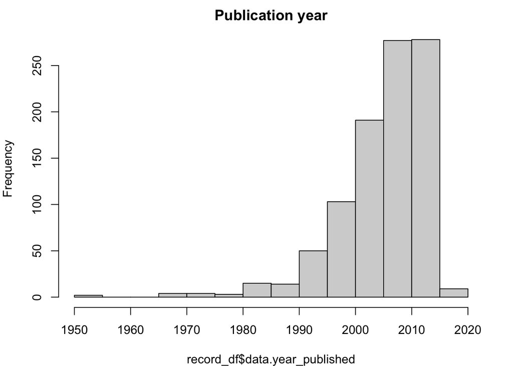

```r
par(mar=c(4,4,2,2))
hist(record_df$data.year_published, main = "Publication year")
```

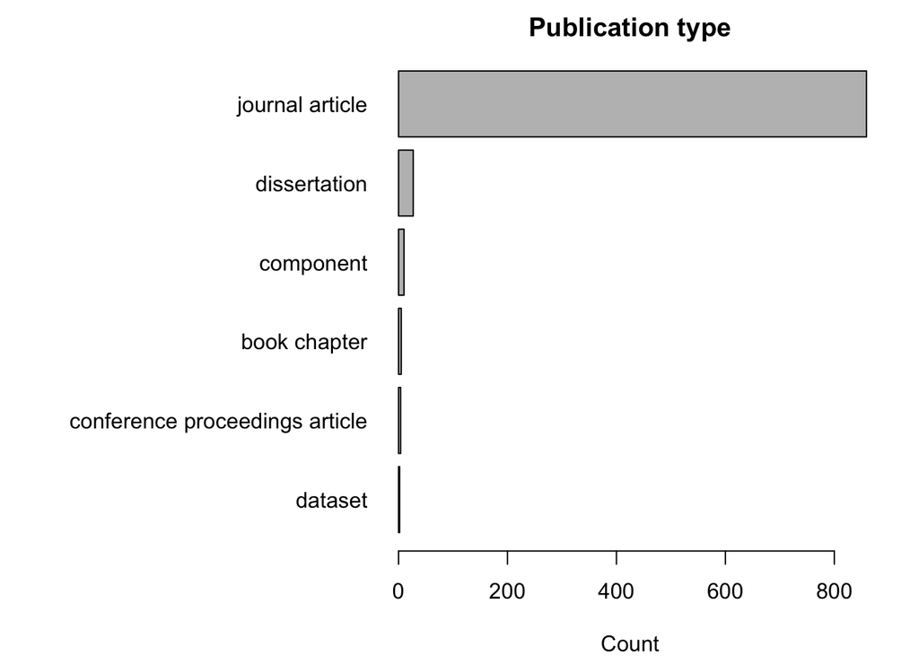

```r
#min(record_df$data.year_published, na.rm = TRUE)
#max(record_df$data.year_published, na.rm = TRUE)

par(mar=c(4,15,2,2))
barplot(sort(table(record_df$data.publication_type)), horiz=TRUE, las=1, xlab = "Count", main = "Publication type")
```

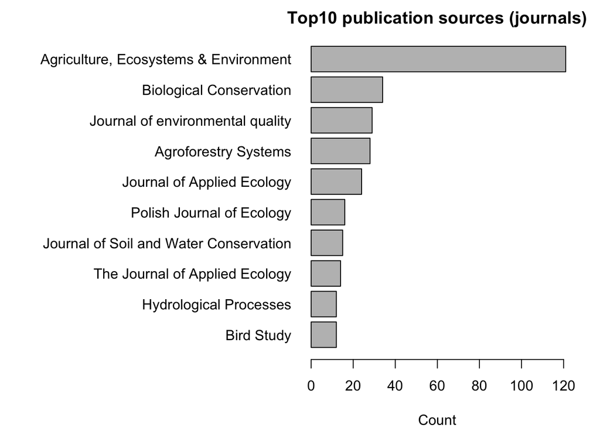

```r
par(mar=c(4,18,2,2))
barplot(sort(sort(table(record_df$data.source$title),decreasing = TRUE)[1:10]), horiz=TRUE, las=1, xlab = "Count", main = "Top10 publication sources (journals)")
```

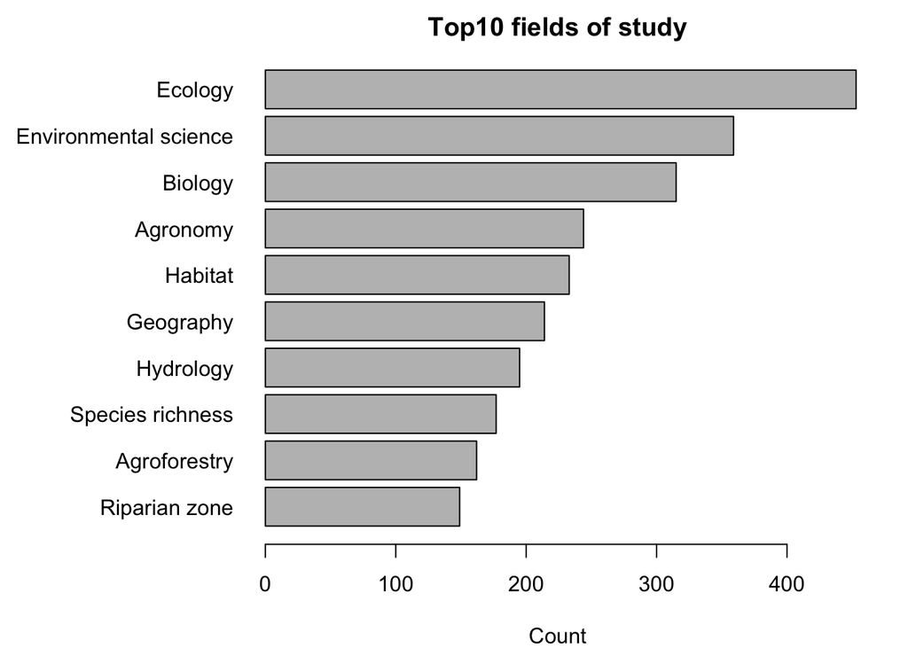

```r
par(mar=c(4,10,2,2))
barplot(sort(sort(table(unlist(record_df$data.fields_of_study)),decreasing = TRUE)[1:10]), horiz=TRUE, las=1, xlab = "Count", main = "Top10 fields of study")
```

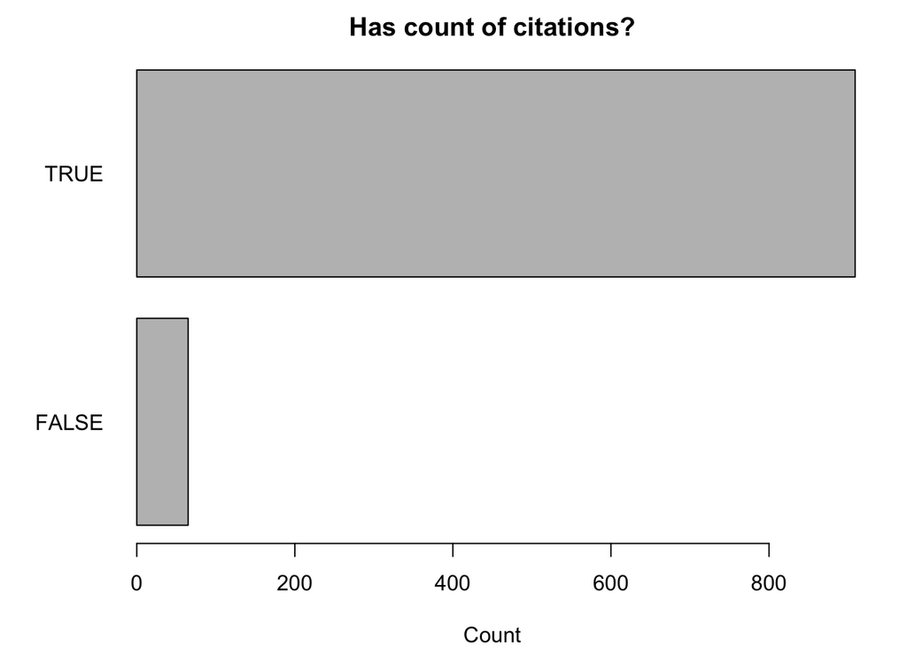

```r
#record_df$data.fields_of_study[[1]][1] #first value from every list for first paper
#record_df$data.fields_of_study[1] #first value from every list for every paper

par(mar=c(4,5,2,2))
barplot(table(!is.na(record_df$data.scholarly_citations_count)), horiz=TRUE, las=1, xlab = "Count", main = "Has count of citations?") #NA should be probably 0
```

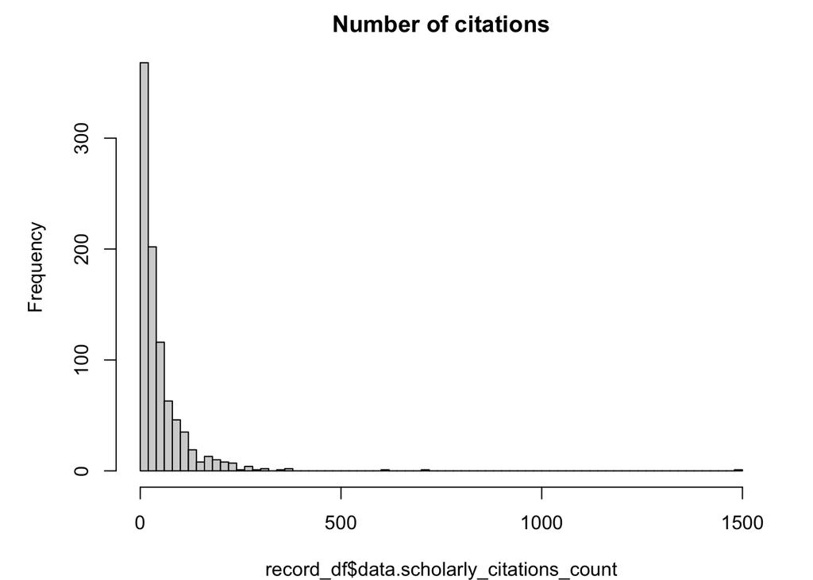

```r
hist(record_df$data.scholarly_citations_count, main = "Number of citations", breaks=100) #ignoring NA
```

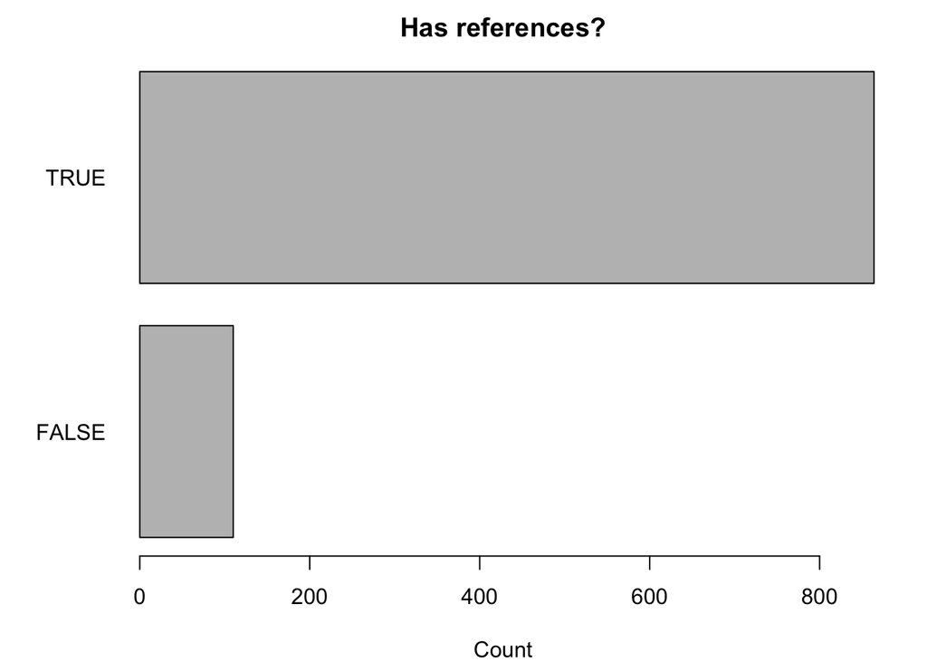

```r
# length(unlist(record_df$data.scholarly_citations)) #45097 total citation LENS ids

par(mar=c(4,5,2,2))
barplot(table(!is.na(record_df$data.references_count)), horiz=TRUE, las=1, xlab = "Count", main = "Has references?")
```

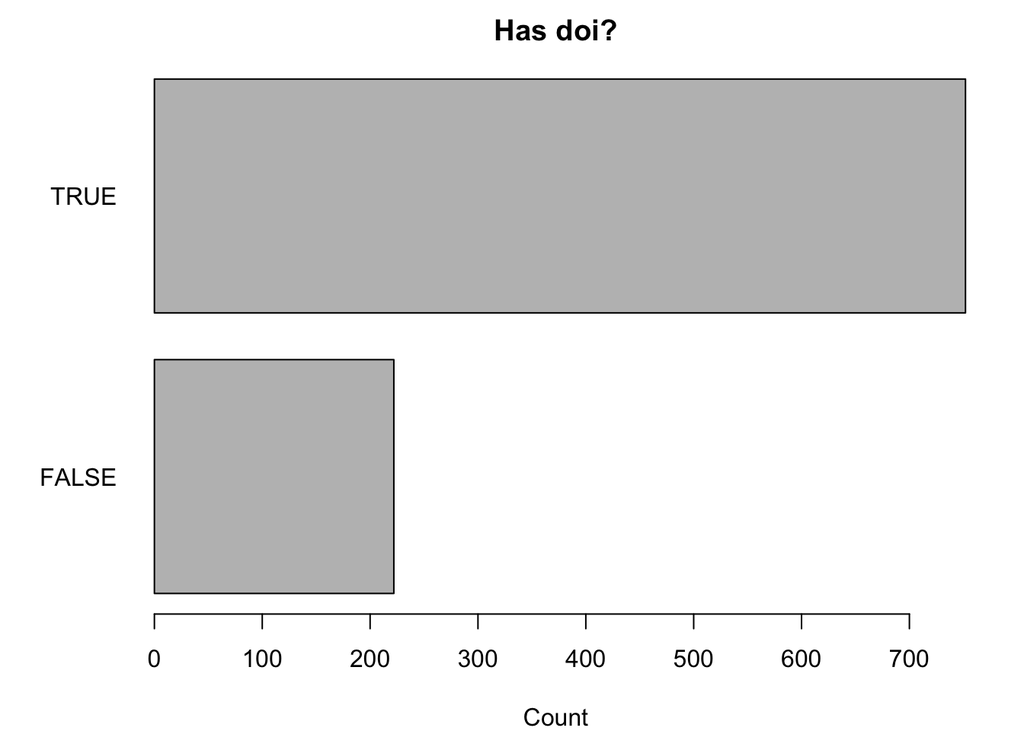

```r
# length(unlist(record_df$data.references)) #30659 total reference LENS ids

doi <- unlist(lapply(record_df$data.external_ids, function(x) x$value[match('doi', x$type)])) #extracting doi for each article

par(mar=c(4,5,2,2))
barplot(table(!is.na(doi)), horiz=TRUE, las=1, xlab = "Count", main = "Has doi?")
```

```r
#table(!is.na(doi))[2] #752 have doi
```

Extract authors data.

```r
#unnest first level of lists for data.authors
record_df_data.authors <- record_df %>% select(data.lens_id, data.title, data.publication_type, data.year_published, data.authors) %>% unnest(data.authors)
#str(record_df_data.authors) #a tibble with some lists of data frames for ids and affiliations
dim(record_df_data.authors) #3549 - one row for each author (but authors can have multiple IDs and affiliations - nexted in author name)
```

```
## [1] 3549    9
```

```r
#names(record_df_data.authors)

#unnest author ids from record_df_data.authors:
record_df_data.authors.ids <- record_df_data.authors %>% select(data.lens_id, data.title, data.publication_type, data.year_published, first_name, last_name, initials, ids) %>% unnest(ids)
#dim(record_df_data.authors.ids) #4052 - one row for each author ID
#names(record_df_data.authors.ids) #a tibble with unnested IDs. Use for igraph: data.lens_id value

record_df_data.authors.ids$Author <- paste(record_df_data.authors.ids$last_name, record_df_data.authors.ids$initials, sep=", ") #add a new column with author name made of last_name and initials

## check overlaps and inconsistencies:
#record_df_data.authors.ids %>% count(Author, type, value, sort = FALSE) %>% View # some authors appear multiple times when multiple ids types are available for them (e.g.     Aavik, T, Park, KJ, Anderson, SH) - selectively remove orcid (as less common).
#record_df_data.authors.ids %>% count(type, Author, value, sort = FALSE) %>% View  # some authors with multiple ids of the same type (e.g. Bigler, F, Brandle, JR, Bright, JA)
#record_df_data.authors.ids %>% count(value, type, Author, sort = FALSE) %>% View # some "multiple" authors per id

#View(arrange(record_df_data.authors.ids[duplicated(record_df_data.authors.ids$value) | duplicated(record_df_data.authors.ids$value, fromLast=TRUE), ], value)) #visual check - some records have more info than others

value_check_df <- arrange(record_df_data.authors.ids[duplicated(record_df_data.authors.ids$value) | duplicated(record_df_data.authors.ids$value, fromLast=TRUE), ], value)

value_check_df$value_Author <- paste(value_check_df$type, value_check_df$value, value_check_df$Author, sep="-")
#View(duplicated(distinct(value_check_df, value_Author, .keep_all = TRUE)), ) #654 rows to be checked!

value_check_df %>%
  group_by(value) %>%
  filter(n()>1) %>%
  distinct(value_Author, .keep_all = TRUE) -> value_check_df2
names(value_check_df2)
```

```
##  [1] "data.lens_id"          "data.title"            "data.publication_type"
##  [4] "data.year_published"   "first_name"            "last_name"
##  [7] "initials"              "type"                  "value"
## [10] "Author"                "value_Author"
```

```r
check_values <- value_check_df2$value[duplicated(value_check_df2$value)] #doi to check


##substitute values with correct author first name and initials:

## fix nr 1
#orcid 0000-0001-5002-106X "Reberg-Horton, SC" to Reberg-Horton, C
#record_df_data.authors.ids[record_df_data.authors.ids$value == check_values[1], c("value", "Author", "first_name", "initials")]
#View(record_df_data.authors.ids[record_df_data.authors.ids$last_name == "Reberg-Horton", ]) #one orcid, 3 different magid! - remove all rows with magid, make first name Chris and initials C
record_df_data.authors.ids <- subset(record_df_data.authors.ids, last_name != "Reberg-Horton" | type != "magid")
dim(record_df_data.authors.ids) #remove all records with magid for this person
```

```
## [1] 4047   10
```

```r
record_df_data.authors.ids$first_name[record_df_data.authors.ids$value == "0000-0001-5002-106X" & record_df_data.authors.ids$last_name == "Reberg-Horton"] <- "Chris"
record_df_data.authors.ids$initials[record_df_data.authors.ids$value == "0000-0001-5002-106X" & record_df_data.authors.ids$Author == "Reberg-Horton, SC"] <- "C"
record_df_data.authors.ids$Author[record_df_data.authors.ids$value == "0000-0001-5002-106X" & record_df_data.authors.ids$Author == "Reberg-Horton, SC"] <- "Reberg-Horton, C"

## fix nr 2
#orcid 0000-0001-5069-0204 "Baker, M" to "Baker, ME" :
#record_df_data.authors.ids[record_df_data.authors.ids$value == check_values[2], c("value", "Author", "first_name", "initials")]
#record_df_data.authors.ids[record_df_data.authors.ids$value == "0000-0001-5069-0204", ]
record_df_data.authors.ids$first_name[record_df_data.authors.ids$value == "0000-0001-5069-0204" & record_df_data.authors.ids$Author == "Baker, M"] <- "Matthew E."
record_df_data.authors.ids$initials[record_df_data.authors.ids$value == "0000-0001-5069-0204" & record_df_data.authors.ids$Author == "Baker, M"] <- "ME"
record_df_data.authors.ids$Author[record_df_data.authors.ids$value == "0000-0001-5069-0204" & record_df_data.authors.ids$Author == "Baker, M"] <- "Baker, ME"

## fix nr 3
#orcid 0000-0001-6431-9959 "Pywell, R" to "Pywell, RF"
#record_df_data.authors.ids[record_df_data.authors.ids$value == check_values[3], c("value", "Author", "first_name", "initials")]
record_df_data.authors.ids$first_name[record_df_data.authors.ids$value == "0000-0001-6431-9959" & record_df_data.authors.ids$Author == "Pywell, R"] <- "Richard F."
record_df_data.authors.ids$initials[record_df_data.authors.ids$value == "0000-0001-6431-9959" & record_df_data.authors.ids$Author == "Pywell, R"] <- "RF"
record_df_data.authors.ids$Author[record_df_data.authors.ids$value == "0000-0001-6431-9959" & record_df_data.authors.ids$Author == "Pywell, R"] <- "Pywell, RF"

## fix nr 4
#orcid 0000-0001-9558-0586  "Marshall, E" to "Marshall, EJP"
#record_df_data.authors.ids[record_df_data.authors.ids$value == check_values[4], c("value", "Author", "first_name", "initials")]
record_df_data.authors.ids$first_name[record_df_data.authors.ids$value == "0000-0001-9558-0586" & record_df_data.authors.ids$Author == "Marshall, E"] <- "E. J. P."
record_df_data.authors.ids$initials[record_df_data.authors.ids$value == "0000-0001-9558-0586" & record_df_data.authors.ids$Author == "Marshall, E"] <- "EJP"
record_df_data.authors.ids$Author[record_df_data.authors.ids$value == "0000-0001-9558-0586" & record_df_data.authors.ids$Author == "Marshall, E"] <- "Marshall, EJP"

## fix nr 5
#orcid 0000-0002-1800-4558 -    Alain   Butet- fix orcid 0000-0002-9173-3466
#orcid 0000-0002-1800-4558 -    Agnes   Fargue-Lelievre - fix orcid 0000-0002-0426-8931 and first name to Agnes
#record_df_data.authors.ids[record_df_data.authors.ids$value == check_values[5], c("value", "Author", "first_name", "initials")]
record_df_data.authors.ids$value[record_df_data.authors.ids$value == "0000-0002-1800-4558" & record_df_data.authors.ids$Author == "Butet, A"] <- "0000-0002-9173-3466"
record_df_data.authors.ids$first_name[record_df_data.authors.ids$value == "0000-0002-1800-4558" & record_df_data.authors.ids$first_name == "A."] <- "Agnes"
record_df_data.authors.ids$value[record_df_data.authors.ids$value == "0000-0002-1800-4558" & record_df_data.authors.ids$Author == "Fargue-Lelièvre, A"] <- "0000-0002-0426-8931"

## fix nr 6
#orcid 0000-0002-4202-2043 fix "NORRDAHL, K" "K" to "Norrdahl, K" "Kai"
#record_df_data.authors.ids[record_df_data.authors.ids$value == check_values[6], c("value", "Author", "first_name", "initials", "last_name")]
record_df_data.authors.ids$first_name[record_df_data.authors.ids$value == "0000-0002-4202-2043" & record_df_data.authors.ids$Author == "NORRDAHL, K"] <- "Kai"
record_df_data.authors.ids$last_name[record_df_data.authors.ids$value == "0000-0002-4202-2043" & record_df_data.authors.ids$Author == "NORRDAHL, K"] <- "Norrdahl"
record_df_data.authors.ids$Author[record_df_data.authors.ids$value == "0000-0002-4202-2043" & record_df_data.authors.ids$Author == "NORRDAHL, K"] <- "Norrdahl, K"

## fix nr 7
#orcid 0000-0003-0300-9951 "Woodcock, B"  "B.A." B" to "Woodcock, BA" "Ben A."
#record_df_data.authors.ids[record_df_data.authors.ids$value == check_values[7], c("value", "Author", "first_name", "initials")]
record_df_data.authors.ids$first_name[record_df_data.authors.ids$value == "0000-0003-0300-9951" & record_df_data.authors.ids$Author == "Woodcock, B"] <- "Ben A."
record_df_data.authors.ids$initials[record_df_data.authors.ids$value == "0000-0003-0300-9951" & record_df_data.authors.ids$Author == "Woodcock, B"] <- "BA"
record_df_data.authors.ids$Author[record_df_data.authors.ids$value == "0000-0003-0300-9951" & record_df_data.authors.ids$Author == "Woodcock, B"] <- "Woodcock, BA"

## fix nr 8
#orcid 0000-0003-1416-6047 "Bourn, NAD" to "Bourn, NA"
#record_df_data.authors.ids[record_df_data.authors.ids$value == check_values[8], c("value", "Author", "first_name", "initials")]
record_df_data.authors.ids$first_name[record_df_data.authors.ids$value == "0000-0003-1416-6047" & record_df_data.authors.ids$Author == "Bourn, NAD"] <- "Nigel A.D."
record_df_data.authors.ids$initials[record_df_data.authors.ids$value == "0000-0003-1416-6047" & record_df_data.authors.ids$Author == "Bourn, NAD"] <- "NA"
record_df_data.authors.ids$Author[record_df_data.authors.ids$value == "0000-0003-1416-6047" & record_df_data.authors.ids$Author == "Bourn, NAD"] <- "Bourn, NA"

## fix nr 9
#orcid 0000-0003-3616-5563 "FINN, J" to "Finn, JA"
#record_df_data.authors.ids[record_df_data.authors.ids$value == check_values[9], c("value", "Author", "first_name", "initials")]
record_df_data.authors.ids$first_name[record_df_data.authors.ids$value == "0000-0003-3616-5563" & record_df_data.authors.ids$Author == "FINN, J"] <- "John A."
record_df_data.authors.ids$initials[record_df_data.authors.ids$value == "0000-0003-3616-5563" & record_df_data.authors.ids$Author == "FINN, J"] <- "JA"
record_df_data.authors.ids$last_name[record_df_data.authors.ids$value == "0000-0003-3616-5563" & record_df_data.authors.ids$Author == "FINN, J"] <- "Finn"
record_df_data.authors.ids$Author[record_df_data.authors.ids$value == "0000-0003-3616-5563" & record_df_data.authors.ids$Author == "FINN, J"] <- "Finn, JA"
```

```r
## fix nr 10
#orcid 0000-0003-3742-7035 "Holland, J" "J.M." to "Holland, JM" "John M."
#record_df_data.authors.ids[record_df_data.authors.ids$value == check_values[10], c("value", "Author", "first_name", "initials")]
record_df_data.authors.ids$first_name[record_df_data.authors.ids$value == "0000-0003-3742-7035" & record_df_data.authors.ids$Author == "Holland, J"] <- "John M."
record_df_data.authors.ids$initials[record_df_data.authors.ids$value == "0000-0003-3742-7035" & record_df_data.authors.ids$Author == "Holland, J"] <- "JM"
record_df_data.authors.ids$Author[record_df_data.authors.ids$value == "0000-0003-3742-7035" & record_df_data.authors.ids$Author == "Holland, J"] <- "Holland, JM"

## fix nr 11
#orcid 000-0003-4225-9451 "Rahman, M" to "Rahman, MM"
#record_df_data.authors.ids[record_df_data.authors.ids$value == check_values[11], c("value", "Author", "first_name", "initials")]
record_df_data.authors.ids$first_name[record_df_data.authors.ids$value == "0000-0003-4225-9451" & record_df_data.authors.ids$Author == "Rahman, M"] <- "Mizanur Md."
record_df_data.authors.ids$initials[record_df_data.authors.ids$value == "0000-0003-4225-9451" & record_df_data.authors.ids$Author == "Rahman, M"] <- "MM"
record_df_data.authors.ids$Author[record_df_data.authors.ids$value == "0000-0003-4225-9451" & record_df_data.authors.ids$Author == "Rahman, M"] <- "Rahman, MM"

## fix nr 12
#orcid 0000-0003-4382-7051 "Sparks, T"  "T.H" to "Sparks, TH" "Tim H."
#record_df_data.authors.ids[record_df_data.authors.ids$value == check_values[12], c("value", "Author", "first_name", "initials")]
record_df_data.authors.ids$first_name[record_df_data.authors.ids$value == "0000-0003-4382-7051" & record_df_data.authors.ids$Author == "Sparks, T"] <- "Tim H."
record_df_data.authors.ids$initials[record_df_data.authors.ids$value == "0000-0003-4382-7051" & record_df_data.authors.ids$Author == "Sparks, T"] <- "TH"
record_df_data.authors.ids$Author[record_df_data.authors.ids$value == "0000-0003-4382-7051" & record_df_data.authors.ids$Author == "Sparks, T"] <- "Sparks, TH"

# check remaining ids:
#dim(record_df_data.authors.ids)
#table(is.na(record_df_data.authors.ids$type)) #no missing values
#table(is.na(record_df_data.authors.ids$value)) #no missing values
#table(record_df_data.authors.ids$type)

#clean by removing orcid if magid is available
record_df_data.authors.ids %>%
    group_by(data.title, Author) %>%
    filter(type==min(type)) -> record_df_data.authors.ids

#table(record_df_data.authors.ids$type) #3468 - magid, 11 - orcid

#check how many authors with same name but different ids
record_df_data.authors.ids %>%
    group_by(Author) %>%
    summarise(count = n_distinct(value)) %>%
    filter(count > 1) -> check_next

#select subset of records where same author name has more than one id for manual checking against affiliations etc., then sort and save into a .csv file:
authors_confounded_ids <- record_df_data.authors.ids[c(record_df_data.authors.ids$Author %in% as.character(check_next$Author)), ]
authors_confounded_ids <- arrange(authors_confounded_ids, Author)

write.csv(authors_confounded_ids, here("data", "lens_confounded_authors_manual_check.csv"))

#dim(check_next) #134 Authors with multiple id values - further checking needed, e.g.:

#example of cleaning these using code, one by one (think of a function to do this?)

## fix nr 13
#View(record_df_data.authors.ids[record_df_data.authors.ids$Author == "Anderson, SH",]) #same as below
#View(record_df_data.authors.ids[record_df_data.authors.ids$Author == as.character(check_next[1,"Author"]), ]) #publication with lens_id 144-115-592-302-602 is a duplicate (conf proceeding) of another article - remove from the authors dataset:
record_df_data.authors.ids <- subset(record_df_data.authors.ids, data.lens_id != "144-115-592-302-602")
record_df <- subset(record_df, data.lens_id != "144-115-592-302-602") #remove from the main dataset

## fix nr 14
#M. Anjum‚ÄêZubair magid    1969021398 to magid 2432178546  Muhammad Anjum-Zubair:
record_df_data.authors.ids$value[record_df_data.authors.ids$value == "1969021398"] <- "2432178546"
record_df_data.authors.ids$last_name[record_df_data.authors.ids$value == "2432178546"] <- "Anjum-Zubair"
record_df_data.authors.ids$first_name[record_df_data.authors.ids$value == "2432178546"] <- "Muhammad"

## fix nr 15
#E.J    Asteraki magid  2638401467 to magid 2869471838  E. J.   Asteraki:
record_df_data.authors.ids$value[record_df_data.authors.ids$value == "2638401467"] <- "2869471838"
record_df_data.authors.ids$first_name[record_df_data.authors.ids$value == "2869471838"] <- "E. J."

## fix nr 16
#S Aviron magid 3062457481 to magid 51778602    Stephanie Aviron:
record_df_data.authors.ids$value[record_df_data.authors.ids$value == "3062457481"] <- "51778602"
record_df_data.authors.ids$first_name[record_df_data.authors.ids$value == "51778602"] <- "Stephanie"

## fix nr 17
#P. Benoit magid    3206497951 and 2164587776 to magid 3206018185   Pierre  Benoit:
record_df_data.authors.ids$value[record_df_data.authors.ids$value == "3206497951"] <- "3206018185"
record_df_data.authors.ids$value[record_df_data.authors.ids$value == "2164587776"] <- "3206018185"
record_df_data.authors.ids$first_name[record_df_data.authors.ids$value == "3206018185"] <- "Pierre"

## fix nr 18
#S Aviron magid 2086633639 to magid 3035619222 Franz    Bigler:
record_df_data.authors.ids$value[record_df_data.authors.ids$value == "2086633639"] <- "3035619222"

## fix nr 19
#J. R.  Brandle magid   3012274858 to magid 1962060530  James R.    Brandle:
record_df_data.authors.ids$value[record_df_data.authors.ids$value == "3012274858"] <- "1962060530"
record_df_data.authors.ids$first_name[record_df_data.authors.ids$value == "1962060530"] <- "James R."

## fix nr 20
#Jenny A.   Bright magid    2762875851, 2095964347 to magid 2127488183  Jennifer Anne   Bright:
record_df_data.authors.ids$value[record_df_data.authors.ids$value == "2762875851"] <- "2127488183"
record_df_data.authors.ids$value[record_df_data.authors.ids$value == "2095964347"] <- "2127488183"
record_df_data.authors.ids$first_name[record_df_data.authors.ids$value == "2127488183"] <- "Jennifer Anne"
```

```r
## fix nr 21
#Fran√ßoise Burel magid 2924376891 to magid 2277833683  Francoise Burel:
record_df_data.authors.ids$value[record_df_data.authors.ids$value == "2924376891"] <- "2277833683"
record_df_data.authors.ids$first_name[record_df_data.authors.ids$value == "2277833683"] <- "Francoise"

## fix nr 22
#L. W.  Burger magid    2924376891 to magid 2150899759  L. Wes  Burger:
record_df_data.authors.ids$value[record_df_data.authors.ids$value == "3178819166"] <- "2150899759"
record_df_data.authors.ids$first_name[record_df_data.authors.ids$value == "2150899759"] <- "L. Wes"

## fix nr 23
# magid 2111030262 to magid 2484271966 Michael R.   Burkart:
record_df_data.authors.ids$value[record_df_data.authors.ids$value == "2111030262"] <- "2484271966"

## fix nr 24
# magid 2760876195 to magid 2423641952 C. Nigel R. Critchley:
record_df_data.authors.ids$value[record_df_data.authors.ids$value == "2760876195"] <- "2423641952"
record_df_data.authors.ids$first_name[record_df_data.authors.ids$value == "2423641952"] <- "C. Nigel R."

## fix nr 25
# magid 1988552287 to magid 2228367754 Philip J. Croxton:
record_df_data.authors.ids$value[record_df_data.authors.ids$value == "1988552287"] <- "2228367754"
record_df_data.authors.ids$first_name[record_df_data.authors.ids$value == "2228367754"] <- "Philip J."

## fix nr 26
# magid 1857011976 to magid 2677325151  Cullum, RF:
record_df_data.authors.ids$value[record_df_data.authors.ids$value == "1857011976"] <- "2677325151"

## fix nr 27
# magid 2132791231 to magid 60885406    De Cauwer, Benny:
record_df_data.authors.ids$value[record_df_data.authors.ids$value == "2132791231"] <- "60885406"
record_df_data.authors.ids$first_name[record_df_data.authors.ids$value == "60885406"] <- "Benny"

## fix nr 28
# magid 2801754577 to magid 2504157055  Derocles, SAP:
record_df_data.authors.ids$value[record_df_data.authors.ids$value == "2801754577"] <- "2504157055"

## fix nr 29
# magid 2872534606 to magid 2112395989  Dollar, Jolie G.:
record_df_data.authors.ids$value[record_df_data.authors.ids$value == "2872534606"] <- "2112395989"
record_df_data.authors.ids$first_name[record_df_data.authors.ids$value == "2112395989"] <- "Jolie G."

## fix nr 30
# magid 2684909858, 2793022476 to magid 1971355974  Dosskey, Michael G.:
record_df_data.authors.ids$value[record_df_data.authors.ids$value == "2684909858"] <- "1971355974"
record_df_data.authors.ids$value[record_df_data.authors.ids$value == "2793022476"] <- "1971355974"
record_df_data.authors.ids$first_name[record_df_data.authors.ids$value == "1971355974"] <- " Michael G."

## fix nr 31
# magid 2808773257 to magid 2764292372  Dutin, Gilles:
record_df_data.authors.ids$value[record_df_data.authors.ids$value == "2808773257"] <- "2764292372"
record_df_data.authors.ids$first_name[record_df_data.authors.ids$value == "2764292372"] <- "Gilles"

## fix nr 32
# magid 2696018409, 3114473581 to magid 410375806   Dutoit, Thierry:
record_df_data.authors.ids$value[record_df_data.authors.ids$value == "2696018409"] <- "410375806"
record_df_data.authors.ids$value[record_df_data.authors.ids$value == "3114473581"] <- "410375806"
record_df_data.authors.ids$first_name[record_df_data.authors.ids$value == "410375806"] <- "Thierry"

## fix nr 33
# magid 2164558504 and magid 2173160061 are different people with same Author Edwards, PJ - add numbers:
record_df_data.authors.ids$Author[record_df_data.authors.ids$value == "2164558504"] <- "Edwards, PJ1"
record_df_data.authors.ids$Author[record_df_data.authors.ids$value == "2173160061"] <- "Edwards, PJ2"

## fix nr 34
# magid 2832089597 to magid 201639963   Eghball, B:
record_df_data.authors.ids$value[record_df_data.authors.ids$value == "2832089597"] <- "201639963"

## fix nr 35
# magid 668900349 to magid 2980463621   Emmingham, WH:
record_df_data.authors.ids$value[record_df_data.authors.ids$value == "668900349"] <- "2980463621"

## fix nr 36
# magid 2154441883 to magid 2676689296  Fox, AF :
record_df_data.authors.ids$value[record_df_data.authors.ids$value == "2154441883"] <- "2676689296"
record_df_data.authors.ids$first_name[record_df_data.authors.ids$value == "2676689296"] <- "Aaron Freeman"

## fix nr 37
# magid 2098462634 to magid 2261690022  Frampton, GK:
record_df_data.authors.ids$value[record_df_data.authors.ids$value == "2098462634"] <- "2261690022"
record_df_data.authors.ids$first_name[record_df_data.authors.ids$value == "2261690022"] <- "Geoffrey K."

## fix nr 38
#publication with lens_id 069-437-241-458-828 is an erratum of another article - remove from the authors dataset:
record_df_data.authors.ids <- subset(record_df_data.authors.ids, data.lens_id != "069-437-241-458-828")
record_df <- subset(record_df, data.lens_id != "069-437-241-458-828") #remove from the main dataset
# magid 2681877430 to magid 2251024960  Franti, TG:
record_df_data.authors.ids$value[record_df_data.authors.ids$value == "2681877430"] <- "2251024960"

## fix nr 39
# magid 2713504129 to magid 2712284677  Fry, Gareth L.A.:
record_df_data.authors.ids$value[record_df_data.authors.ids$value == "2713504129"] <- "2712284677"
record_df_data.authors.ids$first_name[record_df_data.authors.ids$value == "2712284677"] <- "Gareth L.A."

## fix nr 40
# magid 2555564744 to magid 2096759130  Fuller, Robert J.:
record_df_data.authors.ids$value[record_df_data.authors.ids$value == "2555564744"] <- "2096759130"
record_df_data.authors.ids$first_name[record_df_data.authors.ids$value == "2096759130"] <- "Robert J."

## fix nr 41
# magid 2120573253 to magid 2799511157  Gardiner, Tim:
record_df_data.authors.ids$value[record_df_data.authors.ids$value == "2120573253"] <- "2799511157"

## fix nr 42
# magid 3180815816 to magid 2112883227  Garrett, Harold E.:
record_df_data.authors.ids$value[record_df_data.authors.ids$value == "3180815816"] <- "2112883227"
record_df_data.authors.ids$first_name[record_df_data.authors.ids$value == "2112883227"] <- "Harold E."

## fix nr 43
# magid 3117351576 to magid 2153462941  Gilley, JE:
record_df_data.authors.ids$value[record_df_data.authors.ids$value == "3117351576"] <- "2153462941"
```

```r
## fix nr 44
# magid 2565660511, 2070281803 to magid 2145334004  Gilliam, J. Wendell:
record_df_data.authors.ids$value[record_df_data.authors.ids$value == "2565660511"] <- "2145334004"
record_df_data.authors.ids$value[record_df_data.authors.ids$value == "2070281803"] <- "2145334004"
record_df_data.authors.ids$first_name[record_df_data.authors.ids$value == "2145334004"] <- "J. Wendell"

## fix nr 45
#publication with lens_id 038-357-875-647-853 is a duplicate of another article - remove from the authors dataset:
record_df_data.authors.ids <- subset(record_df_data.authors.ids, data.lens_id != "038-357-875-647-853")
record_df <- subset(record_df, data.lens_id != "038-357-875-647-853") #remove from the main dataset

## fix nr 46
# magid 2703779712 to magid 2048417577  Grabow, GL:
record_df_data.authors.ids$value[record_df_data.authors.ids$value == "2703779712"] <- "2048417577"

## fix nr 47
# magid 2907704750 to magid 2047673052  Grala, Robert Konrad:
record_df_data.authors.ids$value[record_df_data.authors.ids$value == "2907704750"] <- "2047673052"
record_df_data.authors.ids$first_name[record_df_data.authors.ids$value == "2047673052"] <- "Robert Konrad"

## fix nr 48
# magid 2078615988 to magid 2132890577  Grice, Philip V.:
record_df_data.authors.ids$value[record_df_data.authors.ids$value == "2078615988"] <- "2132890577"
record_df_data.authors.ids$first_name[record_df_data.authors.ids$value == "2132890577"] <- "Philip V."

## fix nr 49
# magid 1901836219 to magid 2630213313  Gundrey, Anna L:
record_df_data.authors.ids$value[record_df_data.authors.ids$value == "1901836219"] <- "2630213313"
record_df_data.authors.ids$first_name[record_df_data.authors.ids$value == "2630213313"] <- "Anna L."

## fix nr 50
# magid 2515983417 to magid 1995696869  Harrison-Cripps, Jennifer:
record_df_data.authors.ids$value[record_df_data.authors.ids$value == "2515983417"] <- "1995696869"
record_df_data.authors.ids$first_name[record_df_data.authors.ids$value == "1995696869"] <- "Jennifer"

## fix nr 51
# magid 2980501678 to magid 2228816081  Harrison, William:
record_df_data.authors.ids$value[record_df_data.authors.ids$value == "2980501678"] <- "2228816081"
record_df_data.authors.ids$first_name[record_df_data.authors.ids$value == "2228816081"] <- "William"

## fix nr 52
# magid 1880848158 to magid 3177368442  Haughton, Alison J.:
record_df_data.authors.ids$value[record_df_data.authors.ids$value == "1880848158"] <- "3177368442"
record_df_data.authors.ids$first_name[record_df_data.authors.ids$value == "3177368442"] <- "Alison J."

## fix nr 53
# magid 2704085292 to magid 2279446159  Hausammann, Ariane:
record_df_data.authors.ids$value[record_df_data.authors.ids$value == "2704085292"] <- "2279446159"
record_df_data.authors.ids$first_name[record_df_data.authors.ids$value == "2279446159"] <- "Ariane"

## fix nr 54
# magid 2963183393 and 2637350545 to magid 2629351487   Haycock, Nicholas E.:
record_df_data.authors.ids$value[record_df_data.authors.ids$value == "2963183393"] <- "2629351487"
record_df_data.authors.ids$value[record_df_data.authors.ids$value == "2637350545"] <- "2629351487"
record_df_data.authors.ids$first_name[record_df_data.authors.ids$value == "2629351487"] <- "Nicholas E."

## fix nr 55
# magid 3060985268 to magid 2126549186  Herzog, Felix:
record_df_data.authors.ids$value[record_df_data.authors.ids$value == "3060985268"] <- "2126549186"
record_df_data.authors.ids$first_name[record_df_data.authors.ids$value == "2126549186"] <- "Felix"

## fix nr 56
# magid 2711233669 to magid 2635499295  Hirsh, Sarah M.:
record_df_data.authors.ids$value[record_df_data.authors.ids$value == "2711233669"] <- "2635499295"
record_df_data.authors.ids$first_name[record_df_data.authors.ids$value == "2635499295"] <- "Sarah M."

## fix nr 57
# magid 2791690635 to magid 2659214199  Hoagland, Kyle D.:
record_df_data.authors.ids$value[record_df_data.authors.ids$value == "2791690635"] <- "2659214199"
record_df_data.authors.ids$first_name[record_df_data.authors.ids$value == "2659214199"] <- "Kyle D."

## fix nr 58
# magid 2703823451 to magid 2620733497  Huusela-Veistola, Erja:
record_df_data.authors.ids$value[record_df_data.authors.ids$value == "2703823451"] <- "2620733497"
record_df_data.authors.ids$first_name[record_df_data.authors.ids$value == "2620733497"] <- "Erja"

## fix nr 59
# magid 3187419915 to magid 1978911463  Isenhart, TM:
record_df_data.authors.ids$value[record_df_data.authors.ids$value == "3187419915"] <- "1978911463"

## fix nr 60
# magid 2123786699  Jackson, B to Bethanna M. Jackson and Jackson, BM
record_df_data.authors.ids$first_name[record_df_data.authors.ids$value == "2123786699"] <- "Bethanna M."
record_df_data.authors.ids$initials[record_df_data.authors.ids$value == "2123786699"] <- "BM"
record_df_data.authors.ids$Author[record_df_data.authors.ids$value == "2123786699"] <- "Jackson, BM."

## fix nr 61
# magid 3065846024 and 2670851849 to magid 1273417835   Jacot, Katja:
record_df_data.authors.ids$value[record_df_data.authors.ids$value == "3065846024"] <- "1273417835"
record_df_data.authors.ids$value[record_df_data.authors.ids$value == "2670851849"] <- "1273417835"
record_df_data.authors.ids$first_name[record_df_data.authors.ids$value == "1273417835"] <- "Katja"

## fix nr 62
# magid 2167241711 to magid 2169862143  Jeanneret, Philippe:
record_df_data.authors.ids$value[record_df_data.authors.ids$value == "2167241711"] <- "2169862143"
record_df_data.authors.ids$first_name[record_df_data.authors.ids$value == "2169862143"] <- "Philippe"

## fix nr 63
# magid 2976807732 to magid 2671511903  Kajak, Anna:
record_df_data.authors.ids$value[record_df_data.authors.ids$value == "2976807732"] <- "2671511903"
record_df_data.authors.ids$first_name[record_df_data.authors.ids$value == "2671511903"] <- "Anna"

## fix nr 64
# magid 3180674337 to magid 2132390630  Kallenbach, Robert L.:
record_df_data.authors.ids$value[record_df_data.authors.ids$value == "3180674337"] <- "2132390630"
record_df_data.authors.ids$first_name[record_df_data.authors.ids$value == "2132390630"] <- "Robert L."
```

```r
## fix nr 65
# magid 3058132985 to magid 2466309790  Kaushik, Narinder K.:
record_df_data.authors.ids$value[record_df_data.authors.ids$value == "3058132985"] <- "2466309790"
record_df_data.authors.ids$first_name[record_df_data.authors.ids$value == "2466309790"] <- "Narinder K."

## fix nr 66
# magid 3167403767 to magid 3172132651  Kim, D:
record_df_data.authors.ids$value[record_df_data.authors.ids$value == "3167403767"] <- "3172132651"

## fix nr 67
# magid 2632376671 to magid 1999453829  Kirwan, L:
record_df_data.authors.ids$value[record_df_data.authors.ids$value == "2632376671"] <- "1999453829"

## fix nr 68
# magid 2656554574 to magid 2918686731  Kiss, Jozsef:
record_df_data.authors.ids$value[record_df_data.authors.ids$value == "2656554574"] <- "2918686731"
record_df_data.authors.ids$first_name[record_df_data.authors.ids$value == "2918686731"] <- "Jozsef"

## fix nr 69
# magid 2907503280 to magid 3055359434  Klaus, Iris:
record_df_data.authors.ids$value[record_df_data.authors.ids$value == "2907503280"] <- "3055359434"
record_df_data.authors.ids$first_name[record_df_data.authors.ids$value == "3055359434"] <- "Iris"

## fix nr 70
# magid 35993009 to magid 2651887918    Komor, Stephen C.:
record_df_data.authors.ids$value[record_df_data.authors.ids$value == "35993009"] <- "2651887918"
record_df_data.authors.ids$first_name[record_df_data.authors.ids$value == "2651887918"] <- "Stephen C."

## fix nr 71
# magid 2171070111 to magid 2692276939  Kort, J:
record_df_data.authors.ids$value[record_df_data.authors.ids$value == "2171070111"] <- "2692276939"

## fix nr 72
# magid 2672519493 and 2117555699 to magid 2519480210   Kovar, John L.:
record_df_data.authors.ids$value[record_df_data.authors.ids$value == "2672519493"] <- "2519480210"
record_df_data.authors.ids$value[record_df_data.authors.ids$value == "2117555699"] <- "2519480210"
record_df_data.authors.ids$first_name[record_df_data.authors.ids$value == "2519480210"] <- "John L."

## fix nr 73
# magid 2635859285 to magid 266310396   Kromp, Bernhard:
record_df_data.authors.ids$value[record_df_data.authors.ids$value == "2635859285"] <- "266310396"
record_df_data.authors.ids$first_name[record_df_data.authors.ids$value == "266310396"] <- "Bernhard"

## fix nr 74
# magid 2974023335 to magid 2300580621  Kujawa, Krzysztof:
record_df_data.authors.ids$value[record_df_data.authors.ids$value == "2974023335"] <- "2300580621"
record_df_data.authors.ids$first_name[record_df_data.authors.ids$value == "2300580621"] <- "Krzysztof"

## fix nr 75
# magid 3171807434 to magid 3180424817  Kumar, S:
record_df_data.authors.ids$value[record_df_data.authors.ids$value == "3171807434"] <- "3180424817"

## fix nr 76
# magid 2006603341 to magid 2471503772  Kuusemets, V:
record_df_data.authors.ids$value[record_df_data.authors.ids$value == "2006603341"] <- "2471503772"

## fix nr 77
# magid 2556882891 to magid 2629544079  Labanowska-Bury, Dorota:
record_df_data.authors.ids$value[record_df_data.authors.ids$value == "2556882891"] <- "2629544079"
record_df_data.authors.ids$first_name[record_df_data.authors.ids$value == "2629544079"] <- "Dorota"

## fix nr 78
# magid 3201138460 to magid 2336772887  Lack, Peter C.:
record_df_data.authors.ids$value[record_df_data.authors.ids$value == "3201138460"] <- "2336772887"
record_df_data.authors.ids$first_name[record_df_data.authors.ids$value == "2336772887"] <- "Peter C."

## fix nr 79
# magid 2151890652 to magid 2209132334  Landis, Douglas A.:
record_df_data.authors.ids$value[record_df_data.authors.ids$value == "2151890652"] <- "2209132334"
record_df_data.authors.ids$first_name[record_df_data.authors.ids$value == "2209132334"] <- "Douglas A."

## fix nr 80
# magid 2487959036 to magid 2714486801  Lang, Andreas:
record_df_data.authors.ids$value[record_df_data.authors.ids$value == "2487959036"] <- "2714486801"
record_df_data.authors.ids$first_name[record_df_data.authors.ids$value == "2714486801"] <- "Andreas"

## fix nr 81
# magid 2637458295 to magid 2785881690  Le Coeur, Didier:
record_df_data.authors.ids$value[record_df_data.authors.ids$value == "2637458295"] <- "2785881690"
record_df_data.authors.ids$first_name[record_df_data.authors.ids$value == "2785881690"] <- "Didier"

## fix nr 82
# magid 2646321672 to magid 2705540922  Lee, K-:
record_df_data.authors.ids$value[record_df_data.authors.ids$value == "2646321672"] <- "2705540922"
record_df_data.authors.ids$initials[record_df_data.authors.ids$value == "2705540922"] <- "KH"
record_df_data.authors.ids$Author[record_df_data.authors.ids$value == "2705540922"] <- "Lee, K.-H."

## fix nr 83
# orcid 0000-0002-2974-3612 to magid 262327925  Leifert, Carlo:
record_df_data.authors.ids$value[record_df_data.authors.ids$value == "0000-0002-2974-3612"] <- "262327925"
record_df_data.authors.ids$type[record_df_data.authors.ids$value == "262327925"] <- "magid"
record_df_data.authors.ids$first_name[record_df_data.authors.ids$value == "262327925"] <- "Carlo"

## fix nr 84
# magid 2353247364  Lin, C to Lin, CM:
record_df_data.authors.ids$Author[record_df_data.authors.ids$value == "2353247364"] <- "Lin, CM"
record_df_data.authors.ids$initials[record_df_data.authors.ids$value == "2353247364"] <- "CM"

## fix nr 85
# magid 2172060430  Lin, C to Lin, CH:
record_df_data.authors.ids$Author[record_df_data.authors.ids$value == "2172060430"] <- "Lin, CH"
record_df_data.authors.ids$initials[record_df_data.authors.ids$value == "2172060430"] <- "CH"

## fix nr 86
# magid 2558214333 to magid 2111173722  Locke, Martin A.:
record_df_data.authors.ids$value[record_df_data.authors.ids$value == "2558214333"] <- "2111173722"
record_df_data.authors.ids$first_name[record_df_data.authors.ids$value == "2111173722"] <- "Martin A."

## fix nr 87
# magid 2036535872 to magid 2668440904  Ludy, Claudia:
record_df_data.authors.ids$value[record_df_data.authors.ids$value == "2036535872"] <- "2668440904"
record_df_data.authors.ids$first_name[record_df_data.authors.ids$value == "2668440904"] <- "Claudia"

## fix nr 88
# magid 2673012903 to magid 2073885539  Luka, Henryk:
record_df_data.authors.ids$value[record_df_data.authors.ids$value == "2673012903"] <- "2073885539"
record_df_data.authors.ids$first_name[record_df_data.authors.ids$value == "2073885539"] <- "Henryk"
```

```r
## fix nr 89
# magid 2672675688 to magid 2148535374  Madrigal, Ismael:
record_df_data.authors.ids$value[record_df_data.authors.ids$value == "2672675688"] <- "2148535374"
record_df_data.authors.ids$first_name[record_df_data.authors.ids$value == "2148535374"] <- "Ismael"

## fix nr 90
# magid 2777650464 to magid 2679527388  Marshall, EJP:
record_df_data.authors.ids$value[record_df_data.authors.ids$value == "2777650464"] <- "2679527388"
record_df_data.authors.ids$first_name[record_df_data.authors.ids$value == "2679527388"] <- "E. J. P."

## fix nr 91
# magid 2488763253 and 2169347235 to magid 2614404664   Mason, Christopher F.:
record_df_data.authors.ids$value[record_df_data.authors.ids$value == "2488763253"] <- "2614404664"
record_df_data.authors.ids$value[record_df_data.authors.ids$value == "2169347235"] <- "2614404664"
record_df_data.authors.ids$first_name[record_df_data.authors.ids$value == "2614404664"] <- "Christopher F."

## fix nr 92
# magid 3035904792 to magid 2574307034  Matheny, TA:
record_df_data.authors.ids$value[record_df_data.authors.ids$value == "3035904792"] <- "2574307034"
record_df_data.authors.ids$first_name[record_df_data.authors.ids$value == "2574307034"] <- "T. A."

## fix nr 93
# magid 1925609584 to magid 2698835659  Maudsley, Martin:
record_df_data.authors.ids$value[record_df_data.authors.ids$value == "1925609584"] <- "2698835659"
record_df_data.authors.ids$first_name[record_df_data.authors.ids$value == "2698835659"] <- "Martin"

## fix nr 94
# magid 3043996765 and 2305706538 to magid 2636487500   McGregor, Keith C.:
record_df_data.authors.ids$value[record_df_data.authors.ids$value == "3043996765"] <- "2636487500"
record_df_data.authors.ids$value[record_df_data.authors.ids$value == "2305706538"] <- "2636487500"
record_df_data.authors.ids$first_name[record_df_data.authors.ids$value == "2636487500"] <- "Keith C."

## fix nr 95
# magid 2763873611 to magid 1989141265  Merot, P:
record_df_data.authors.ids$value[record_df_data.authors.ids$value == "2763873611"] <- "1989141265"

## fix nr 96
# magid 2600237656 and 2911599796 to magid 2123581830   Moorman, Thomas B.:
record_df_data.authors.ids$value[record_df_data.authors.ids$value == "2600237656"] <- "2123581830"
record_df_data.authors.ids$value[record_df_data.authors.ids$value == "2911599796"] <- "2123581830"
record_df_data.authors.ids$first_name[record_df_data.authors.ids$value == "2123581830"] <- "Thomas B."

## fix nr 97
# magid 2658743912 to magid 2649586665  Mountford, JO:
record_df_data.authors.ids$value[record_df_data.authors.ids$value == "2658743912"] <- "2649586665"

## fix nr 98
# magid 3130902738 and magid 2011986067 are different people with same Author Nieminen, M - add numbers:
record_df_data.authors.ids$Author[record_df_data.authors.ids$value == "3130902738"] <- "Nieminen, M1"
record_df_data.authors.ids$Author[record_df_data.authors.ids$value == "2011986067"] <- "Nieminen, M2"

## fix nr 99
# magid 2694091630 to magid 1972478770  Olechowicz, E:
record_df_data.authors.ids$value[record_df_data.authors.ids$value == "2694091630"] <- "1972478770"

## fix nr 100
# magid 3053178510 to magid 2484470641  Otto, Stefan:
record_df_data.authors.ids$value[record_df_data.authors.ids$value == "3053178510"] <- "2484470641"
record_df_data.authors.ids$first_name[record_df_data.authors.ids$value == "2484470641"] <- "Stefan"

## fix nr 101
# magid 2140679796 to magid 3026817438  Parkin, TB:
record_df_data.authors.ids$value[record_df_data.authors.ids$value == "2140679796"] <- "3026817438"

## fix nr 102
# magid 2805976163 to magid 2462194467  Petit, S:
record_df_data.authors.ids$value[record_df_data.authors.ids$value == "2805976163"] <- "2462194467"

## fix nr 103
# magid 2577431138 to magid 335605033   Plantegenest, M:
record_df_data.authors.ids$value[record_df_data.authors.ids$value == "2577431138"] <- "335605033"

## fix nr 104
# magid 2636185091 to magid 2332866815  Puckett, K. Marc:
record_df_data.authors.ids$value[record_df_data.authors.ids$value == "2636185091"] <- "2332866815"
record_df_data.authors.ids$first_name[record_df_data.authors.ids$value == "2332866815"] <- "K. Marc"

## fix nr 105
# orcid 0000-0003-4225-9451 to magid 3039998318 Rahman, MM:
record_df_data.authors.ids$value[record_df_data.authors.ids$value == "0000-0003-4225-9451"] <- "3039998318"
record_df_data.authors.ids$type[record_df_data.authors.ids$value == "3039998318"] <- "magid"

## fix nr 106
# magid 2603965551 to magid 2717609878  Rands, MRW:
record_df_data.authors.ids$value[record_df_data.authors.ids$value == "2603965551"] <- "2717609878"
record_df_data.authors.ids$first_name[record_df_data.authors.ids$value == "2717609878"] <- "M. R. W."

## fix nr 107
# magid 3005417640 to magid 1484388629  Rasa, K:
record_df_data.authors.ids$value[record_df_data.authors.ids$value == "3005417640"] <- "1484388629"

## fix nr 108
# magid 3078110253 to magid 2169169971 Real, Benoit:
record_df_data.authors.ids$value[record_df_data.authors.ids$value == "3078110253"] <- "2169169971"
record_df_data.authors.ids$first_name[record_df_data.authors.ids$value == "2169169971"] <- "Benoit"
record_df_data.authors.ids$last_name[record_df_data.authors.ids$value == "2169169971"] <- "Real"
record_df_data.authors.ids$Author[record_df_data.authors.ids$value == "2169169971"] <- "Real, B"

## fix nr 109
# magid 345764407 to magid 241315796    Rewa, CA:
record_df_data.authors.ids$value[record_df_data.authors.ids$value == "345764407"] <- "241315796"

## fix nr 110
# magid 2981211890 to magid 2295855806  Robertson, Duncan:
record_df_data.authors.ids$value[record_df_data.authors.ids$value == "2981211890"] <- "2295855806"
record_df_data.authors.ids$first_name[record_df_data.authors.ids$value == "2295855806"] <- "Duncan"

## fix nr 111
# magid 2992761126 to magid 2115363680  Sauer, Thomas J.:
record_df_data.authors.ids$value[record_df_data.authors.ids$value == "2992761126"] <- "2115363680"
record_df_data.authors.ids$first_name[record_df_data.authors.ids$value == "2115363680"] <- "Thomas J."

## fix nr 112
# magid 3063215599 to magid 2158388169 Beatrice Schupbach:
record_df_data.authors.ids$value[record_df_data.authors.ids$value == "3063215599"] <- "2158388169"
record_df_data.authors.ids$first_name[record_df_data.authors.ids$value == "2158388169"] <- "Beatrice"
record_df_data.authors.ids$last_name[record_df_data.authors.ids$value == "2158388169"] <- "Schupbach"
record_df_data.authors.ids$Author[record_df_data.authors.ids$value == "2158388169"] <- "Schupbach, B"
```

```r
## fix nr 113
# magid 2723720423 to magid 2280134996  Senoussi, Rachid:
record_df_data.authors.ids$value[record_df_data.authors.ids$value == "2723720423"] <- "2280134996"
record_df_data.authors.ids$first_name[record_df_data.authors.ids$value == "2280134996"] <- "Rachid"

## fix nr 114
# magid 3197067095 to magid 2290748772  Shaw, David R.:
record_df_data.authors.ids$value[record_df_data.authors.ids$value == "3197067095"] <- "2290748772"
record_df_data.authors.ids$first_name[record_df_data.authors.ids$value == "2290748772"] <- "David R."

## fix nr 115
# magid 2702469488 and 3156102152 to magid 2554417526   Sotherton, Nicolas W.:
record_df_data.authors.ids$value[record_df_data.authors.ids$value == "2702469488"] <- "2554417526"
record_df_data.authors.ids$value[record_df_data.authors.ids$value == "3156102152"] <- "2554417526"
record_df_data.authors.ids$first_name[record_df_data.authors.ids$value == "2554417526"] <- "Nicolas W."

## fix nr 116
# magid 2723483715 to magid 1594900231  Spruill, Timothy B.:
record_df_data.authors.ids$value[record_df_data.authors.ids$value == "2723483715"] <- "1594900231"
record_df_data.authors.ids$first_name[record_df_data.authors.ids$value == "1594900231"] <- "Timothy B."

## fix nr 117
# magid 2120825161 to magid 3121162453  Sullivan, DS:
record_df_data.authors.ids$value[record_df_data.authors.ids$value == "2120825161"] <- "3121162453"

## fix nr 118
# magid 2941149995 to magid 2941113392  Syversen, Nina:
record_df_data.authors.ids$value[record_df_data.authors.ids$value == "2941149995"] <- "2941113392"
record_df_data.authors.ids$first_name[record_df_data.authors.ids$value == "2941113392"] <- "Nina"

## fix nr 119
# magid 3208328870 to magid 2977658324  Tallowin, Jerry R.:
record_df_data.authors.ids$value[record_df_data.authors.ids$value == "3208328870"] <- "2977658324"
record_df_data.authors.ids$first_name[record_df_data.authors.ids$value == "2977658324"] <- "Jerry R."

## fix nr 120
# magid 2308657864 and 2034382432 to magid 2311089936   Tattersall, Francoise H.:
record_df_data.authors.ids$value[record_df_data.authors.ids$value == "2308657864"] <- "2311089936"
record_df_data.authors.ids$value[record_df_data.authors.ids$value == "2034382432"] <- "2311089936"
record_df_data.authors.ids$first_name[record_df_data.authors.ids$value == "2311089936"] <- "Francoise H."

## fix nr 121
#publication with lens_id 028-717-958-656-943 is a corrigendum of another article - remove from the authors dataset:
record_df_data.authors.ids <- subset(record_df_data.authors.ids, data.lens_id != "028-717-958-656-943")
record_df <- subset(record_df, data.lens_id != "028-717-958-656-943") #remove from the main dataset
# magid 2643251359 to magid 2109741121  Thomas, C. F. George:
record_df_data.authors.ids$value[record_df_data.authors.ids$value == "2643251359"] <- "2109741121"
record_df_data.authors.ids$first_name[record_df_data.authors.ids$value == "2109741121"] <- "C. F. George"

## fix nr 122
# magid 2504210219 to magid 2074586124  Tierney, Dennis P.:
record_df_data.authors.ids$value[record_df_data.authors.ids$value == "2504210219"] <- "2074586124"
record_df_data.authors.ids$first_name[record_df_data.authors.ids$value == "2074586124"] <- "Dennis P."

## fix nr 123
# magid 3072427598 and 3000541873 to magid 2231106999   Tomer, Mark D.:
record_df_data.authors.ids$value[record_df_data.authors.ids$value == "3072427598"] <- "2231106999"
record_df_data.authors.ids$value[record_df_data.authors.ids$value == "3000541873"] <- "2231106999"
record_df_data.authors.ids$first_name[record_df_data.authors.ids$value == "2231106999"] <- "Mark D."

## fix nr 124
#publication with lens_id 144-115-592-302-602 is a duplicate of another article - remove from the authors dataset:
record_df_data.authors.ids <- subset(record_df_data.authors.ids, data.lens_id != "144-115-592-302-602")
record_df <- subset(record_df, data.lens_id != "144-115-592-302-602") #remove from the main dataset
# magid 3179029498 to magid 297348948   Udawatta, Ranjith P.:
record_df_data.authors.ids$value[record_df_data.authors.ids$value == "3179029498"] <- "297348948"
record_df_data.authors.ids$first_name[record_df_data.authors.ids$value == "297348948"] <- "Ranjith P."

## fix nr 125
# magid 2015391856 to magid 2626502302 Jaana Uusi-Kamppa:
record_df_data.authors.ids$value[record_df_data.authors.ids$value == "2015391856"] <- "2626502302"
record_df_data.authors.ids$last_name[record_df_data.authors.ids$value == "2626502302"] <- "Uusi-Kamppa"
record_df_data.authors.ids$Author[record_df_data.authors.ids$value == "2626502302"] <- "Uusi-Kamppa, J"

## fix nr 126
# magid 2645408306 to magid 2778234347  Paul C. J. van Rijn:
record_df_data.authors.ids$value[record_df_data.authors.ids$value == "2645408306"] <- "2778234347"
record_df_data.authors.ids$first_name[record_df_data.authors.ids$value == "2778234347"] <- "Paul C. J."

## fix nr 127
# orcis 0000-0002-5425-241X to magid 2242996170 Vellidis, George:
record_df_data.authors.ids$value[record_df_data.authors.ids$value == "0000-0002-5425-241X"] <- "2242996170"
record_df_data.authors.ids$type[record_df_data.authors.ids$value == "2242996170"] <- "magid"
record_df_data.authors.ids$first_name[record_df_data.authors.ids$value == "2242996170"] <- "George"

## fix nr 128
# magid 2923553631 to magid 2151746401  Vickery, JA:
record_df_data.authors.ids$value[record_df_data.authors.ids$value == "2923553631"] <- "2151746401"

## fix nr 129
#publication with lens_id 180-256-208-559-265 is a duplicate of another article - remove from the authors dataset:
record_df_data.authors.ids <- subset(record_df_data.authors.ids, data.lens_id != "180-256-208-559-265")
record_df <- subset(record_df, data.lens_id != "180-256-208-559-265") #remove from the main dataset
# magid 2609554350 to magid 2053514387  Vidon, Philippe:
record_df_data.authors.ids$value[record_df_data.authors.ids$value == "2609554350"] <- "2053514387"
record_df_data.authors.ids$first_name[record_df_data.authors.ids$value == "2053514387"] <- "Philippe"

## fix nr 130
# magid 1470328431 to magid 2907375745  Francisco Diaz-Fierros Viqueira:
record_df_data.authors.ids$value[record_df_data.authors.ids$value == "1470328431"] <- "2907375745"
record_df_data.authors.ids$first_name[record_df_data.authors.ids$value == "2907375745"] <- "Francisco Diaz-Fierros"
```

```r
## fix nr 131
# magid 2431967633 to magid 2039405485  Felix L. Wackers:
record_df_data.authors.ids$value[record_df_data.authors.ids$value == "2431967633"] <- "2039405485"
record_df_data.authors.ids$first_name[record_df_data.authors.ids$value == "2039405485"] <- "Felix L."
record_df_data.authors.ids$last_name[record_df_data.authors.ids$value == "2039405485"] <- "Wackers"
record_df_data.authors.ids$Author[record_df_data.authors.ids$value == "2039405485"] <- "Wackers, FL"

## fix nr 132
# magid 2702179144 to magid 2114825854  Walton, NJ:
record_df_data.authors.ids$value[record_df_data.authors.ids$value == "2702179144"] <- "2114825854"

## fix nr 133
# magid 2900559531 to magid 2345524932  David F. Webber:
record_df_data.authors.ids$value[record_df_data.authors.ids$value == "2900559531"] <- "2345524932"
record_df_data.authors.ids$first_name[record_df_data.authors.ids$value == "2345524932"] <- "David F."

## fix nr 134
# magid 2426540393 to magid 2778576021  T. M. West:
record_df_data.authors.ids$value[record_df_data.authors.ids$value == "2426540393"] <- "2778576021"
record_df_data.authors.ids$first_name[record_df_data.authors.ids$value == "2778576021"] <- "T. M."

## fix nr 135
# magid 2557083686 to magid 2259983837  White, Roger:
record_df_data.authors.ids$value[record_df_data.authors.ids$value == "2557083686"] <- "2259983837"
record_df_data.authors.ids$first_name[record_df_data.authors.ids$value == "2259983837"] <- "Roger"

## fix nr 136
# magid 2432530054 to magid 2135638108 Randall G. Williams:
record_df_data.authors.ids$value[record_df_data.authors.ids$value == "2432530054"] <- "2135638108"
record_df_data.authors.ids$first_name[record_df_data.authors.ids$value == "2135638108"] <- "Randall G."

## fix nr 137
# magid 2112963049 and magid 2132846614 are different people with same Author Wilson, JD - add numbers:
record_df_data.authors.ids$Author[record_df_data.authors.ids$value == "2112963049"] <- "Wilson, JD1"
record_df_data.authors.ids$Author[record_df_data.authors.ids$value == "2132846614"] <- "Wilson, JD2"

## fix nr 138
# magid 2762378604 to magid 2143915691 Karin Winkler:
record_df_data.authors.ids$value[record_df_data.authors.ids$value == "2762378604"] <- "2143915691"
record_df_data.authors.ids$first_name[record_df_data.authors.ids$value == "2143915691"] <- "Karin"

## fix nr 139
#publication with lens_id 052-121-834-684-873 is a duplicate of another article - remove from the authors dataset:
record_df_data.authors.ids <- subset(record_df_data.authors.ids, data.lens_id != "052-121-834-684-873")
record_df <- subset(record_df, data.lens_id != "052-121-834-684-873") #remove from the main dataset
# magid 3114300772 and 2600713750 to magid 2284387554   Woodbury, BL:
record_df_data.authors.ids$value[record_df_data.authors.ids$value == "3114300772"] <- "2284387554"
record_df_data.authors.ids$value[record_df_data.authors.ids$value == "2600713750"] <- "2284387554"

## fix nr 140
# magid 2581687904 and 2988530751 and 3002827677 to magid 2083225834 Stephen D. Wratten:
record_df_data.authors.ids$value[record_df_data.authors.ids$value == "2581687904"] <- "2083225834"
record_df_data.authors.ids$value[record_df_data.authors.ids$value == "2988530751"] <- "2083225834"
record_df_data.authors.ids$value[record_df_data.authors.ids$value == "3002827677"] <- "2083225834"
record_df_data.authors.ids$first_name[record_df_data.authors.ids$value == "2083225834"] <- "Stephen D."

## fix nr 141
# magid 3130371620 and 2422744197 to magid 2010841276   Wyss, Eric:
record_df_data.authors.ids$value[record_df_data.authors.ids$value == "3130371620"] <- "2010841276"
record_df_data.authors.ids$value[record_df_data.authors.ids$value == "2422744197"] <- "2010841276"
record_df_data.authors.ids$first_name[record_df_data.authors.ids$value == "2010841276"] <- "Eric"

## fix nr 142
# magid 3120318805 and 2630821214 to magid 2472204622   Yahner, Richard H.:
record_df_data.authors.ids$value[record_df_data.authors.ids$value == "3120318805"] <- "2472204622"
record_df_data.authors.ids$value[record_df_data.authors.ids$value == "2630821214"] <- "2472204622"
record_df_data.authors.ids$first_name[record_df_data.authors.ids$value == "2472204622"] <- "Richard H."

## fix nr 143
# magid 2703993885 to magid 2108106037  Yli-Halla, M:
record_df_data.authors.ids$value[record_df_data.authors.ids$value == "2703993885"] <- "2108106037"

## fix nr 144
# magid 2488034465 to magid 838701823   Zangger, Adrian:
record_df_data.authors.ids$value[record_df_data.authors.ids$value == "2488034465"] <- "838701823"
record_df_data.authors.ids$first_name[record_df_data.authors.ids$value == "838701823"] <- "Adrian"

## fix nr 145
# magid 2683713286 to magid 2429685876  Zyczynska-Baloniak, Irena:
record_df_data.authors.ids$value[record_df_data.authors.ids$value == "2683713286"] <- "2429685876"
record_df_data.authors.ids$first_name[record_df_data.authors.ids$value == "2429685876"] <- "Irena"

## fix nr 146
# magid 2661713076 to magid 2168280740  Carmona, DM:
record_df_data.authors.ids$value[record_df_data.authors.ids$value == "2661713076"] <- "2168280740"
record_df_data.authors.ids$first_name[record_df_data.authors.ids$value == "2168280740"] <- "Dora Mabel"

## fix nr 147
# magid 2688966438 to magid 2718685829  Corda, E:
record_df_data.authors.ids$value[record_df_data.authors.ids$value == "2688966438"] <- "2718685829"

# #check again how many authors with same name but different ids
# record_df_data.authors.ids %>%
#     group_by(Author) %>%
#     summarise(count = n_distinct(value)) %>%
#     filter(count > 1) -> check_next
# # check_next

#dim(record_df) #968 articles
#dim(record_df_data.authors.ids) #3453 authors

write.csv(record_df_data.authors.ids, here("data", "record_df_data.authors.ids_cleaned.csv")) #save dataframe as csv

save(record_df, file = here("data", "LENS_dataframe_cleaned.RData")) #save semi-cleaned LENS output as a Rdata object

####### finished cleaning authors ids data frame
```

## Clean affiliation info

Author information stored on this data frame is not cleaned.

Note: considered using refsplitr package, but it also requires manually reviewing and fixing difficult cases, so it is unlikely to simplify this process, given the amount of information and its format.

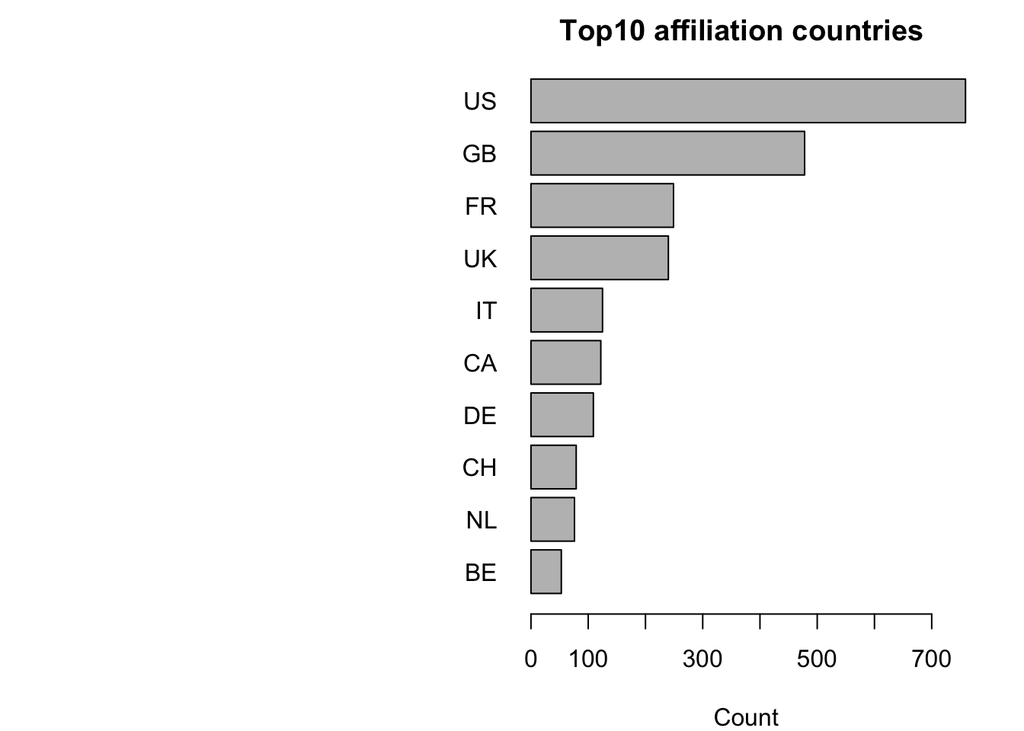

```r
#unnest  affiliations from record_df_data.authors:
record_df_data.authors.aff <- record_df_data.authors %>% select(data.lens_id, data.title, data.publication_type, data.year_published, first_name, last_name, initials, affiliations) %>% unnest(affiliations)
#dim(record_df_data.authors.aff) #2968 - some articles have missing data, esp country ID
#names(record_df_data.authors.aff) #a tibble with unnested ids use for igraph: data.lens_id value
#View(record_df_data.authors.aff)
#table(record_df_data.authors.aff$grid_id, useNA = "always") #780 missing
#table(record_df_data.authors.aff$country_code, useNA = "always")
#table(is.na(record_df_data.authors.aff$country_code)) #885 missing country ID - may need to impute - try https://www.grid.ac/ Global Research Identifier Database (GRID) with name (affiliation name)

## make a subset with missing country_code data - for visual checks:
sub_aff <- record_df_data.authors.aff[is.na(record_df_data.authors.aff$country_code), ]
#dim(sub_aff)
#View(sub_aff)
#View(table(sub_aff$name))
#View(record_df_data.authors.aff[!is.na(record_df_data.authors.aff$country_code) & record_df_data.authors.aff$country_code == "NL", ])


## fix affiliations nr 1
# resolve institutions with grid_id but no country code: grid.414548.8, grid.11417.32, grid.4461.7 = FR (France), grid.475190.e = JO (Jordan)
#table(sub_aff$grid_id)
record_df_data.authors.aff[record_df_data.authors.aff$grid_id %in% c("grid.11417.32","grid.414548.8", "grid.4461.7"), ]$country_code <- "FR"
record_df_data.authors.aff[record_df_data.authors.aff$grid_id %in% c("grid.475190.e"), ]$country_code <- "JO"


## fix affiliations nr 2
#extract most common country names and their variants from affiliations in "name" and assign country_code (https://www.geonames.org/countries/):
#View(record_df_data.authors.aff[grep("Poland", record_df_data.authors.aff$name), ])
record_df_data.authors.aff[grep("UK", record_df_data.authors.aff$name), ]$country_code <- "UK"
record_df_data.authors.aff[grep("U.K.", record_df_data.authors.aff$name), ]$country_code <- "UK"
record_df_data.authors.aff[grep("U. K.", record_df_data.authors.aff$name), ]$country_code <- "UK"
record_df_data.authors.aff[grep("United Kingdom", record_df_data.authors.aff$name), ]$country_code <- "UK"
record_df_data.authors.aff[grep("Great Britain", record_df_data.authors.aff$name), ]$country_code <- "UK"
record_df_data.authors.aff[grep("Scotland", record_df_data.authors.aff$name), ]$country_code <- "UK"
record_df_data.authors.aff[grep("USA", record_df_data.authors.aff$name), ]$country_code <- "US"
record_df_data.authors.aff[grep("U.S.A.", record_df_data.authors.aff$name), ]$country_code <- "US"
record_df_data.authors.aff[grep("United States", record_df_data.authors.aff$name), ]$country_code <- "US"
record_df_data.authors.aff[grep("Netherlands", record_df_data.authors.aff$name), ]$country_code <- "NL"
record_df_data.authors.aff[grep("Switzerland", record_df_data.authors.aff$name), ]$country_code <- "SZ"
record_df_data.authors.aff[grep("France", record_df_data.authors.aff$name), ]$country_code <- "FR"
record_df_data.authors.aff[grep("Italy", record_df_data.authors.aff$name), ]$country_code <- "IT"
record_df_data.authors.aff[grep("Germany", record_df_data.authors.aff$name), ]$country_code <- "GM"
record_df_data.authors.aff[grep("Finland", record_df_data.authors.aff$name), ]$country_code <- "FI"
record_df_data.authors.aff[grep("Japan", record_df_data.authors.aff$name), ]$country_code <- "JA"
record_df_data.authors.aff[grep("Poland", record_df_data.authors.aff$name), ]$country_code <- "PL"
record_df_data.authors.aff[grep("Canada", record_df_data.authors.aff$name), ]$country_code <- "CA"
record_df_data.authors.aff[grep("Argentina", record_df_data.authors.aff$name), ]$country_code <- "AR"
record_df_data.authors.aff[grep("Belgium", record_df_data.authors.aff$name), ]$country_code <- "BE"
record_df_data.authors.aff[grep("Spain", record_df_data.authors.aff$name), ]$country_code <- "SP"
record_df_data.authors.aff[grep("China", record_df_data.authors.aff$name), ]$country_code <- "CH"
record_df_data.authors.aff[grep("Estonia", record_df_data.authors.aff$name), ]$country_code <- "EN"
record_df_data.authors.aff[grep("Norway", record_df_data.authors.aff$name), ]$country_code <- "NO"
record_df_data.authors.aff[grep("Sweden", record_df_data.authors.aff$name), ]$country_code <- "SW"
record_df_data.authors.aff[grep("Denmark", record_df_data.authors.aff$name), ]$country_code <- "DA"
record_df_data.authors.aff[grep("Austria", record_df_data.authors.aff$name), ]$country_code <- "AU"
record_df_data.authors.aff[grep("Indonesia", record_df_data.authors.aff$name), ]$country_code <- "ID"
record_df_data.authors.aff[grep("New Zealand", record_df_data.authors.aff$name), ]$country_code <- "NZ"
record_df_data.authors.aff[grep("Australia", record_df_data.authors.aff$name), ]$country_code <- "AS"
record_df_data.authors.aff[grep("Taiwan", record_df_data.authors.aff$name), ]$country_code <- "TW"
record_df_data.authors.aff[grep("Slovakia", record_df_data.authors.aff$name), ]$country_code <- "LO"
record_df_data.authors.aff[grep("Luxembourg", record_df_data.authors.aff$name), ]$country_code <- "LU"


## fix affiliations nr 3
#For the remaining records use other information from affiliations in "name" (e.g. region, city, institution names) and use it to assign country_code (https://www.geonames.org/countries/):
record_df_data.authors.aff[grep("British", record_df_data.authors.aff$name), ]$country_code <- "UK"
record_df_data.authors.aff[grep("Devon", record_df_data.authors.aff$name), ]$country_code <- "UK"
record_df_data.authors.aff[grep("Norfolk", record_df_data.authors.aff$name), ]$country_code <- "UK"
record_df_data.authors.aff[grep("Chinese", record_df_data.authors.aff$name), ]$country_code <- "CH"
record_df_data.authors.aff[grep("Rennes", record_df_data.authors.aff$name), ]$country_code <- "FR"
record_df_data.authors.aff[grep("Paris", record_df_data.authors.aff$name), ]$country_code <- "FR"
record_df_data.authors.aff[grep("Lille", record_df_data.authors.aff$name), ]$country_code <- "FR"
record_df_data.authors.aff[grep("Nancy", record_df_data.authors.aff$name), ]$country_code <- "FR"
record_df_data.authors.aff[grep("Canadian", record_df_data.authors.aff$name), ]$country_code <- "CA"
record_df_data.authors.aff[grep("Ontario", record_df_data.authors.aff$name), ]$country_code <- "CA"
record_df_data.authors.aff[grep("Québec", record_df_data.authors.aff$name), ]$country_code <- "CA"
record_df_data.authors.aff[grep("Montréal", record_df_data.authors.aff$name), ]$country_code <- "CA"
record_df_data.authors.aff[grep("Nebraska", record_df_data.authors.aff$name), ]$country_code <- "US"
record_df_data.authors.aff[grep("Virginia", record_df_data.authors.aff$name), ]$country_code <- "US"
record_df_data.authors.aff[grep("Maryland", record_df_data.authors.aff$name), ]$country_code <- "US"
record_df_data.authors.aff[grep("Texas", record_df_data.authors.aff$name), ]$country_code <- "US"
record_df_data.authors.aff[grep("Iowa", record_df_data.authors.aff$name), ]$country_code <- "US"
record_df_data.authors.aff[grep("Louisiana", record_df_data.authors.aff$name), ]$country_code <- "US"
record_df_data.authors.aff[grep("Kentucky", record_df_data.authors.aff$name), ]$country_code <- "US"
record_df_data.authors.aff[grep("Lincoln", record_df_data.authors.aff$name), ]$country_code <- "US"
record_df_data.authors.aff[grep("Missouri", record_df_data.authors.aff$name), ]$country_code <- "US"
record_df_data.authors.aff[grep("Wisconsin", record_df_data.authors.aff$name), ]$country_code <- "US"
record_df_data.authors.aff[grep("Delaware", record_df_data.authors.aff$name), ]$country_code <- "US"
record_df_data.authors.aff[grep("New Hampshire", record_df_data.authors.aff$name), ]$country_code <- "US"
record_df_data.authors.aff[grep("California", record_df_data.authors.aff$name), ]$country_code <- "US"
record_df_data.authors.aff[grep("Columbia", record_df_data.authors.aff$name), ]$country_code <- "US"
record_df_data.authors.aff[grep("Polish", record_df_data.authors.aff$name), ]$country_code <- "PL"
record_df_data.authors.aff[grep("Lublin", record_df_data.authors.aff$name), ]$country_code <- "PL"
record_df_data.authors.aff[grep("Hobart", record_df_data.authors.aff$name), ]$country_code <- "AS"
record_df_data.authors.aff[grep("Monash", record_df_data.authors.aff$name), ]$country_code <- "AS"
record_df_data.authors.aff[grep("Scottish", record_df_data.authors.aff$name), ]$country_code <- "UK"
record_df_data.authors.aff[grep("Belgorod", record_df_data.authors.aff$name), ]$country_code <- "RU"
record_df_data.authors.aff[grep("Russian", record_df_data.authors.aff$name), ]$country_code <- "RU"
record_df_data.authors.aff[grep("Kavala", record_df_data.authors.aff$name), ]$country_code <- "GR"
record_df_data.authors.aff[grep("Brno", record_df_data.authors.aff$name), ]$country_code <- "EZ"
record_df_data.authors.aff[grep("Padova", record_df_data.authors.aff$name), ]$country_code <- "IT"
record_df_data.authors.aff[grep("La Mancha", record_df_data.authors.aff$name), ]$country_code <- "SP"

record_df_data.authors.aff[grep("Agricultural Research Center", record_df_data.authors.aff$name), ]$country_code <- "FI"
record_df_data.authors.aff[grep("Institut national de la recherche agronomique", record_df_data.authors.aff$name), ]$country_code <- "FR"
record_df_data.authors.aff[grep("Edward Grey Institute of Field Ornithology", record_df_data.authors.aff$name), ]$country_code <- "UK"
record_df_data.authors.aff[grep("NERC", record_df_data.authors.aff$name), ]$country_code <- "UK"
record_df_data.authors.aff[grep("Technische", record_df_data.authors.aff$name), ]$country_code <- "GM"
record_df_data.authors.aff[grep("Sol Agro et hydrosystème Spatialisation", record_df_data.authors.aff$name), ]$country_code <- "FR"
record_df_data.authors.aff[grep("Southeast Watershed Research Lab", record_df_data.authors.aff$name), ]$country_code <- "US"
record_df_data.authors.aff[grep("IRSA", record_df_data.authors.aff$name), ]$country_code <- "IT"
record_df_data.authors.aff[grep("Hill & Mountain Research Centre", record_df_data.authors.aff$name), ]$country_code <- "UK"
record_df_data.authors.aff[grep("Nova Scotia Agricultural College", record_df_data.authors.aff$name), ]$country_code <- "CA"
record_df_data.authors.aff[grep("Wellington Management Company", record_df_data.authors.aff$name), ]$country_code <- "US"
record_df_data.authors.aff[grep("The Lodge", record_df_data.authors.aff$name), ]$country_code <- "UK"
record_df_data.authors.aff[grep("Science and Health", record_df_data.authors.aff$name), ]$country_code <- "AS"
record_df_data.authors.aff[grep("Plant and Ecological Sciences l", record_df_data.authors.aff$name), ]$country_code <- "NZ"
record_df_data.authors.aff[grep("Cooperative Research Centre", record_df_data.authors.aff$name), ]$country_code <- "AS"
record_df_data.authors.aff[grep("Plant Ecology and Nature Conservation", record_df_data.authors.aff$name), ]$country_code <- "NL"
record_df_data.authors.aff[grep("Facultad de Ciencias Exactas y Naturales", record_df_data.authors.aff$name), ]$country_code <- "AR"

##Note: only 75 left unresolved - too vague, unless going back to original papers to see whole affliation info

par(mar=c(4,18,2,2))
barplot(sort(sort(table(record_df_data.authors.aff$country_code),decreasing = TRUE)[1:10]), horiz=TRUE, las=1, xlab = "Count", main = "Top10 affiliation countries ")
```

```r
#save affiliations table
write.csv(record_df_data.authors.aff, here("data", "record_df_data.authors.aff_cleaned.csv"))
#record_df_data.authors.aff <- read.csv(here("data", "record_df_data.authors.aff_cleaned.csv"))

#Note: did not clean actual institutional affiliation info ("name"), only country codes
```

Data wrangling and cleaning summary:  
- Flattened some of the tables into data frames (author identity info, affiliation country info)  
- Author data: cleaned ids, names and initials - Affiliation data: main cleaning and imputation of missing country code values done (only 75 records left with unassigned country code), grid.id not cleaned or imputed (seem to be more tidy)

#load(file = here(“data”, “LENS_dataframe_cleaned.RData”)) #loads semi-cleaned LENS output from a Rdata object - “record_df”